# PHYS 210 Day 11

### 2026 - 10 - 21

Agenda:

1. Announcements: **Test 3 (Days 09–10 + dictionaries): Mon Oct 26 – Fri Oct 30** · Practice Test 3 is live
2. Reading 11 recap, Q&A and polling questions: from Euler's method to `solve_ivp()`
3. Group Worksheet 11

## Reading recap, Q&A and polling questions

One step at a time, then from the Euler loop to `solve_ivp()`: `derivs`, `sol.t` and `sol.y`, `t_eval`, events

## Solving an ODE step by step

The ball from Preclass 11: $\dfrac{dh}{dt} = v$, $\dfrac{dv}{dt} = -g$, start $h(0) = h_0 = 0$, $v(0) = v_0 = 10$ m/s. So `state = [h, v]`, `state0 = [h0, v0]`

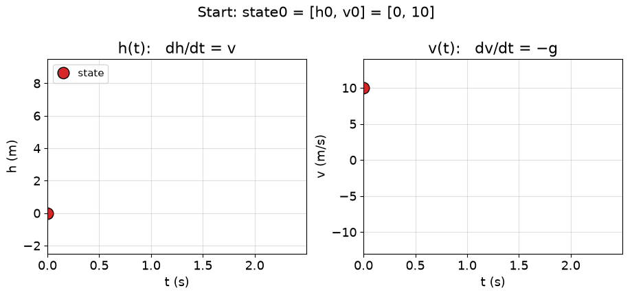

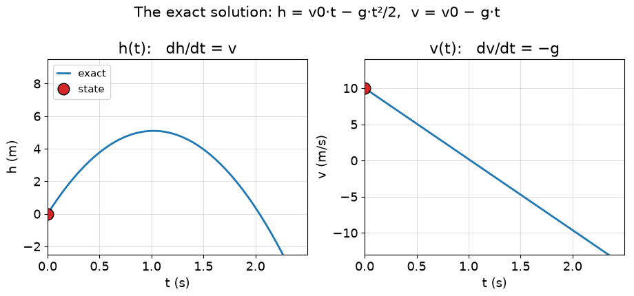

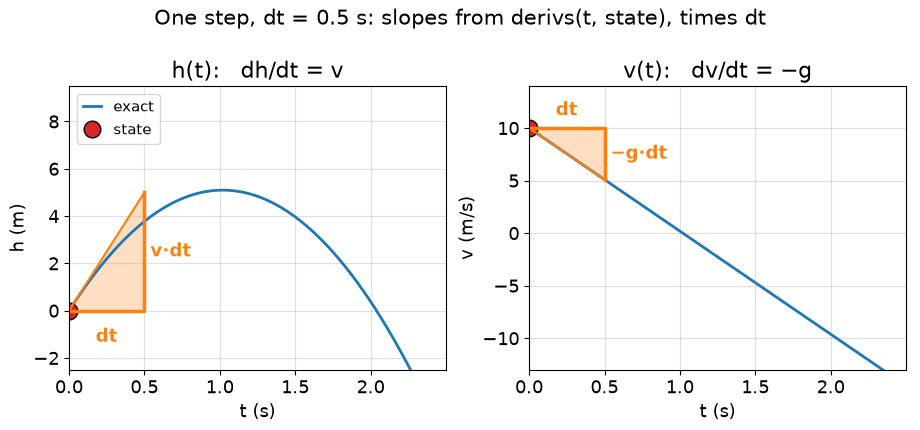

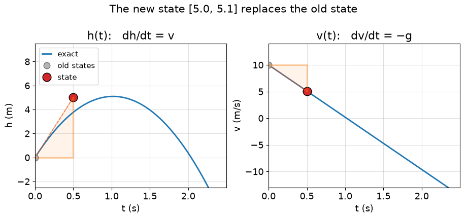

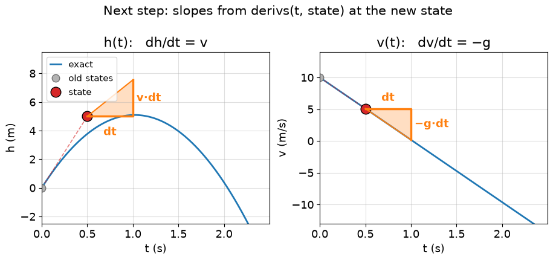

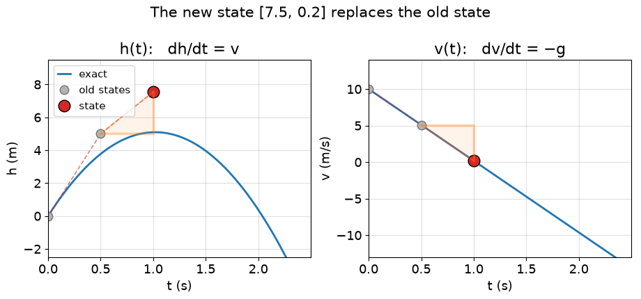

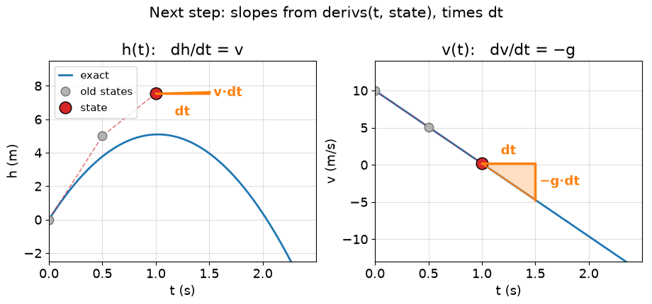

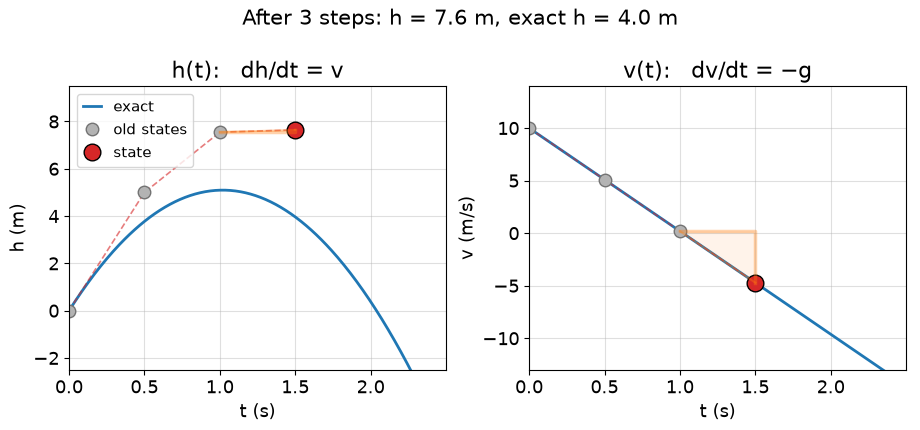

### The same three steps in code

`derivs` gives the slopes, the step multiplies them by `dt`, the new state replaces the old one

```python
def derivs(t, state):
    h, v = state
    return [v, -9.81]                   # [dh/dt, dv/dt]

dt = 0.5
t, state = 0, [0, 10]                   # state0 = [h0, v0]
for step in range(3):
    dhdt, dvdt = derivs(t, state)       # the slopes at the old state
    h, v = state
    state = [h + dhdt * dt, v + dvdt * dt]   # new state replaces old
    t = t + dt
    print(t, [round(x, 1) for x in state])
```

## Reading recap: from the Euler loop to `solve_ivp()`

| Ingredient | Euler loop (11.1 names) | `solve_ivp()` (11.2) |
| --- | --- | --- |
| the physics | the update lines `h + t_step * v`, `v + t_step * a` | `derivs(t, state)` returns `[dh/dt, dv/dt]` = `[v, -g]` |
| the time span | `t_start`, `t_end` | `t_span = (0, 2)` |
| the initial conditions | `h_start`, `v_start` (= `h0`, `v0`) | `state0 = [h0, v0]` |
| the step size | `t_step` (= `dt`): you choose it, fixed | the solver chooses; cap it with `max_step=dt` |

```
sol = solve_ivp(derivs, t_span, state0)    # derivs without ( )
```

- The loop is gone: `solve_ivp()` does the stepping. Your job: the physics in `derivs`
- From here on: `state`, `state0`, `derivs`, `dt`, `t_span` (the Euler column keeps the Preclass 11.1 names)

### `derivs(t, state)`: what goes in, what comes out

```
def derivs(t, state):
    h, v = state            # in: the time, then the current state
    return [v, -9.81]       # out: [dh/dt, dv/dt]
```

- In: always `t` first, then `state`, even if `t` is not used
- Out: the **derivatives** of the state (the slopes of the step triangles), in the **same order** as the state. Not the new state: there is no `dt` in `derivs`
- `solve_ivp()` calls `derivs` many times, at times it chooses

### Reading the solution: `sol.t` and `sol.y`

```
sol = solve_ivp(derivs, t_span, state0)
```

- `sol.t`: 1D array of the times
- `sol.y`: 2D array, **rows = state variables**, **columns = times**
- `sol.y[0]`: all the heights. `sol.y[1]`: all the velocities
- `sol.y[:, 0]`: the state at the first time, `state0 = [h0, v0]`. `sol.y[0, -1]`: the height at the last time

### Which times come back: `t_eval` vs the solver's steps

- No `t_eval`: `sol.t` holds the solver's own steps: uneven, and you do not choose them
- `max_step=dt` only caps the solver's step size: more steps, still the solver's times
- `t_eval=times`: `sol.t` is exactly your array (inside `t_span`). The solver still steps on its own inside
- Either way `sol.y` has one column per time in `sol.t`

### Events: `terminal` and `direction`

```
def hit_ground(t, state):
    return state[0]            # an event when this crosses 0
hit_ground.terminal = True     # stop the solver there
hit_ground.direction = -1      # only from + to -

sol = solve_ivp(derivs, (0, 5), state0, events=[hit_ground])
```

- Return a value that is 0 at the event: "at 4 m" → `state[0] - 4`
- `terminal`: `True` stops; `False` (default) only records the time
- `direction`: `-1` from + to −, `+1` from − to +, `0` (default) both
- Set the attributes after the `def`, not inside it

### Events and `t_eval` together

- A terminal event stops the solver early, so `sol.t` stops early too
- With `t_eval`: `sol.t` holds only your times **before** the stop
- The event time is **not** added to `sol.t`. It is in `sol.t_events[0]`

**Poll Q1:** The state is `[h, v]`. What does this print?

```python
import numpy as np
from scipy.integrate import solve_ivp

def derivs(t, state):
    h, v = state
    return [-9.81, v]

sol = solve_ivp(derivs, [0, 1], [0, 0], t_eval=[0, 1])
print(np.round(sol.y[:, -1], 2))
```

A) `[-4.91 -9.81]`  
B) `[-9.81 0. ]`  
C) `[ 0. -9.81]`  
D) Error: the order does not matter

**Poll Q2:** What does this print?

```python
import numpy as np
from scipy.integrate import solve_ivp

def derivs(t, state):
    h, v = state
    return [v, -9.81]

sol = solve_ivp(derivs, [0, 2], [0, 10], t_eval=np.linspace(0, 2, 5))
print(np.round(sol.y[1], 2))
```

A) `[0. 3.77 5.1 3.96 0.38]`  
B) `[10. 5.1 0.19 -4.72 -9.62]`  
C) `[3.77 5.1 ]`  
D) `[ 0. 10.]`

**Poll Q3:** What does this print?

```python
import numpy as np
from scipy.integrate import solve_ivp

def derivs(t, state):
    h, v = state
    return [v, -9.81]

sol = solve_ivp(derivs, [0, 2], [0, 10], max_step=0.01,
                t_eval=np.linspace(0, 2, 5))
print(len(sol.t), sol.y.shape)
```

A) `5 (2, 5)`  
B) `201 (2, 201)`  
C) `5 (2, 201)`  
D) `5 (5, 2)`

**Poll Q4:** A ball is thrown up at 10 m/s from the ground. What does this print?

```python
import numpy as np
from scipy.integrate import solve_ivp

def derivs(t, state):
    h, v = state
    return [v, -9.81]

def at_4m(t, state):
    return state[0] - 4
at_4m.terminal = True
at_4m.direction = 1

sol = solve_ivp(derivs, [0, 3], [0, 10], events=[at_4m])
print(np.round(sol.t_events[0], 2), round(sol.t[-1], 2))
```

A) `[0.55] 0.55`  
B) `[1.49] 1.49`  
C) `[0.55] 3.0`  
D) `[0.55 1.49] 3.0`

### Events and `t_eval` together: thrown up at 5 m/s from 1 m high

```
def hit_ground(t, state):
    return state[0]
hit_ground.terminal = True
hit_ground.direction = -1

sol = solve_ivp(derivs, [0, 3], [1, 5], t_eval=np.linspace(0, 3, 7),
                events=[hit_ground])
print(sol.t)              # [0.  0.5 1. ]
print(sol.t_events[0])    # [1.19]
```

- The ball lands at $t = 1.19$ s and the solver stops: `sol.t` keeps only the `t_eval` times before that
- The event time is in `sol.t_events[0]`, not in `sol.t`

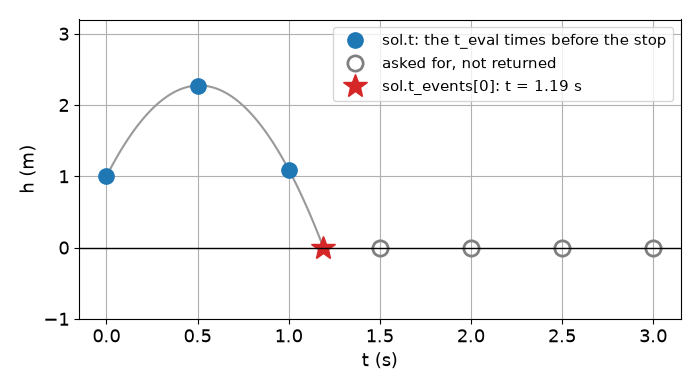

## Tools compute, YOU verify

- Euler with a big `dt` drifts away from the true answer (step by step, `dt = 0.5`: 7.6 m instead of 4.0 m): you will measure it in Homework 12
- `solve_ivp()` chooses its own steps and controls the error. It can still give a smooth, wrong answer: a `derivs` in the wrong order (Poll Q1) runs without an error
- So check every solution: a known case ($h_{max} = v_0^2 / 2g$), conservation of energy, limits, units

## Coming next week: Project A

Your own investigation with `solve_ivp`. Some possibilities:

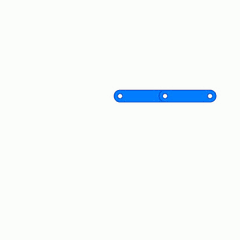

**Double pendulum**

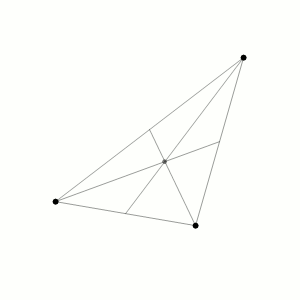

**Three-body problem**

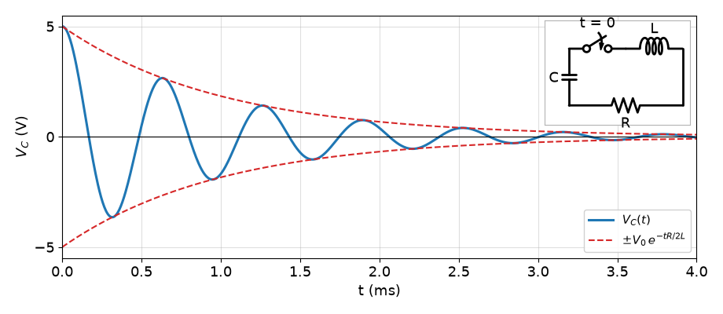

**LRC circuit: a decaying oscillation**

[figure not shown]

**Your own idea**

Animations from Wikimedia Commons: [“Double pendulum simulation”](https://commons.wikimedia.org/wiki/File:Double_pendulum_simulation.gif) by Zvika (CC0, resized) · [“Three-body Problem Animation with COM”](https://commons.wikimedia.org/wiki/File:Three-body_Problem_Animation_with_COM.gif) by Dnttllthmmnm, [CC BY-SA 4.0](https://creativecommons.org/licenses/by-sa/4.0/)

# The rest of today, and before you leave

- **Group Worksheet 11** (Electric Field Hockey with `solve_ivp`: the puck's `diff_eqns`, `sol.y`, a stop-at-the-wall event, a goal check, and `t_eval` with the event): link on Canvas; one driver per task, swap each task; checkpoint with a TA after Task 2
- **Homework 11** (a comet's close approach to Earth, with `solve_ivp`) due Mon Oct 26, 9:00 am. **Restart Kernel and Run All Cells before you export**
- **Preclass 12** (`solve_ivp` 2: 2D motion and orbits) due Mon Oct 26, 9:00 am
- **Test 3** (Days 09–10 + dictionaries) Mon Oct 26 – Fri Oct 30 · Practice Test 3 is live